# iDEP: Investigating Differentially Expressed Genes

## If this site has contributed to your work, please cite our article:

Ge, S.X., Son, E.W. & Yao, R. iDEP: an integrated web application for differential expression and pathway analysis of RNA-Seq data. BMC Bioinformatics 19, 534 (2018). https://doi.org/10.1186/s12859-018-2486-6

## Summary

Read Counts data were analyzed using iDEP v2.4.3. The data was first filtered to remove reads below 0.5 CPM in at least 1 sample. Then the data was transformed with EdgeR using a pseudocount of 4. Missing values were imputed using geneMedian.

After mapping, there are 42278 unique genes in 31 samples. Of the 30756 genes passed filter, 30695 were converted to Ensembl/STRING gene IDs in our database. The remaining 61 genes were kept in the data using original IDs.

Differential expression analysis was performed using DESeq2 with an FDR cutoff of 0.1 and a minimum fold-change threshold of 2. Standard Wald test was used and independent filtering was disabled.

## Selected Comparison: WT_&*40_CGY-WT*&_0_CGY

Up-regulated genes: 7

Down-regulated genes: 6

## Top Up-regulated Genes

```r
if (!is.null(params$up_genes_table) && nrow(params$up_genes_table) > 0) {
  kbl(params$up_genes_table, escape = FALSE) %>%
    kable_classic(full_width = FALSE, html_font = "Cambria")
} else {
  print("No up-regulated genes found for this comparison.")
}
```

| Symbol | Ensembl ID | log2 FC | Adj. P-value | Description |
| --- | --- | --- | --- | --- |
| BRA022378 | BRA022378 | 3.952 | 9.46e-02 | AT3G19010 (E=2e-177) \| oxidoreductase, 2OG-Fe(II) oxygenase family protein |
| BRA004512 | BRA004512 | 3.133 | 7.20e-03 | AT2G46740 (E=2e-304) \| FAD-binding domain-containing protein |
| BRA016689 | BRA016689 | 2.569 | 3.61e-02 | AT1G14670 (E=5e-300) \| endomembrane protein 70, putative |
| BRA005238 | BRA005238 | 2.459 | 8.31e-02 | AT2G36870 (E=7e-165) \| xyloglucan:xyloglucosyl transferase, putative / xyloglucan endotransglycosylase, putative / endo-xyloglucan transferase, putative |
| BRA022830 | BRA022830 | 1.933 | 9.44e-02 | AT1G06190 (E=2e-062) \| ATP binding / ATPase, coupled to transmembrane movement of ions, phosphorylative mechanism |
| BRA029041 | BRA029041 | 1.802 | 9.67e-02 | AT5G54160 (E=5e-197) ATOMT1, OMT1 \| ATOMT1 (O-METHYLTRANSFERASE 1) |
| BRA028924 | BRA028924 | 1.786 | 4.74e-02 | AT5G56030 (E=0.0) HSP81-2, ERD8, HSP90.2 \| HSP81-2 (HEAT SHOCK PROTEIN 81-2) |

## Top Down-regulated Genes

```r
if (!is.null(params$down_genes_table) && nrow(params$down_genes_table) > 0) {
  kbl(params$down_genes_table, escape = FALSE) %>%
    kable_classic(full_width = FALSE, html_font = "Cambria")
} else {
  print("No down-regulated genes found for this comparison.")
}
```

| Symbol | Ensembl ID | log2 FC | Adj. P-value | Description |
| --- | --- | --- | --- | --- |
| BRA005423 | BRA005423 | -2.443 | 4.74e-02 | AT2G34420 (E=8e-101) LHB1B2, LHCB1.5 \| LHB1B2 |
| BRA012891 | BRA012891 | -2.426 | 1.78e-03 | AT3G50750 (E=1e-111) \| brassinosteroid signalling positive regulator-related |
| BRA041075 | BRA041075 | -2.150 | 4.74e-02 |  |
| BRA015788 | BRA015788 | -2.032 | 8.31e-02 | AT1G76100 (E=1e-048) PETE1 \| PETE1 (PLASTOCYANIN 1) |
| BRA003122 | BRA003122 | -1.694 | 4.74e-02 |  |
| BRA002537 | BRA002537 | -1.510 | 9.44e-02 | AT5G59730 (E=2e-262) ATEXO70H7 \| ATEXO70H7 (EXOCYST SUBUNIT EXO70 FAMILY PROTEIN H7) |

## DEG Heatmap

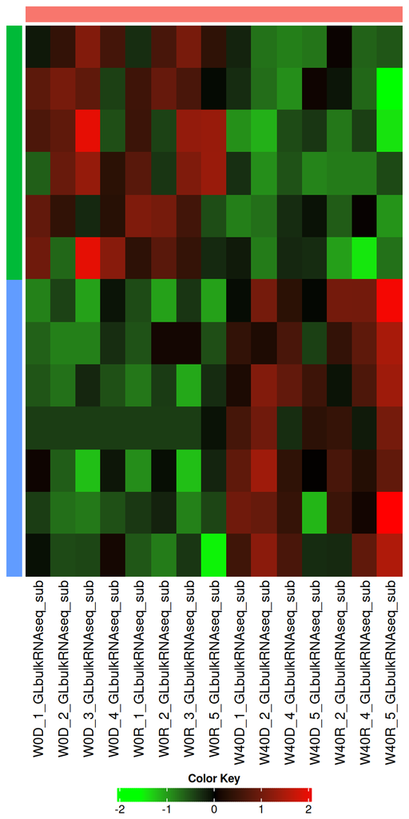

```r
if (!is.null(params$heat_data) && !is.null(params$heat_bar)) {
  heat_colors <- unlist(strsplit(params$heatmap_color_select, "-"))

  deg_heatmap(
    df = params$heat_data,
    bar = params$heat_bar,
    heatmap_color_select = heat_colors,
    cluster_rows = FALSE
  )
}
```

## Volcano Plot

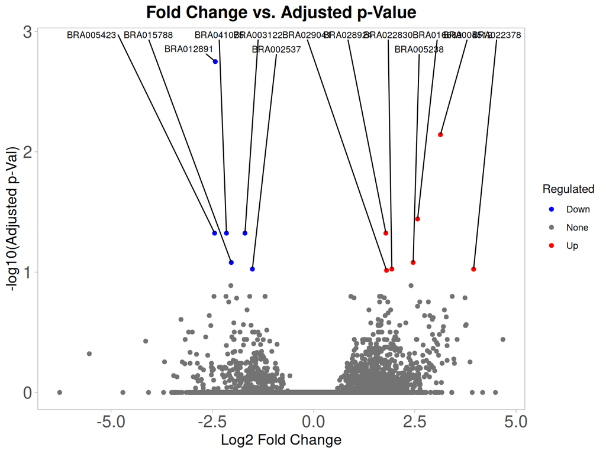

```r
if (!is.null(params$vol_data) && !is.null(params$vol_data$data)) {
  p <- plot_volcano(
    data = params$vol_data$data,
    plot_colors = params$plot_colors,
    anotate_genes = params$gene_labels_volcano
  )
  p <- refine_ggplot2(
    p = p,
    gridline = params$plot_grid_lines,
    ggplot2_theme = params$ggplot2_theme
  )
  print(p)
}
```